# Assignment 2

### CSC478

#### Brian Craft

All the necessary libraries are imported for the assingment.

```python
import pandas
import numpy
import os
import matplotlib.pyplot as plt
%matplotlib inline
from sklearn.feature_extraction import DictVectorizer
from sklearn import neighbors, tree, naive_bayes
from sklearn import preprocessing
from sklearn.cross_validation import train_test_split
from sklearn.metrics import classification_report
from sklearn.metrics import confusion_matrix
from sklearn import cross_validation
from sklearn.cross_validation import KFold
from sklearn.lda import LDA
from sklearn import tree
from IPython.display import Image
```

## Problem 1

### Part A - B

For problem 1, I only made use of the pandas and numpy packages. I used the OS module to change my working directory.

Here, I changed my working directory.

```python
os.chdir('/Users/Brian/Desktop/Assignment_2')
#os.chdir('C:/Users/bcraft/Downloads/Desktop/Assignment_2')
```

Next the necessary datasets are loaded in. The train and test datasets have been transposed, so each row is represented by a document and each column is represented by a term. In this case, we end up with 800 training documents and 200 test documents containing 5,500 terms.

```python
train = pandas.read_csv('trainMatrixModified.txt', sep = '\t', header = None).T
train.shape
```

```
(800, 5500)
```

```python
test = pandas.read_csv('testMatrixModified.txt', sep = '\t', header = None).T
test.shape
```

```
(200, 5500)
```

```python
test_labels = pandas.read_csv('testClasses.txt', sep = '\t', header = None, index_col = 0)
test_labels.shape
```

```
(200, 1)
```

```python
train_labels = pandas.read_csv('trainClasses.txt', sep = '\t', header = None, index_col = 0)
train_labels.shape
```

```
(800, 1)
```

#### The below function, k_nearest_neighbor takes 6 paramters

```
train: document term matrix in a pandas dataframe
test: a document term matrix in a pandas dataframe to be classified
train_labels: a dataframe containing the class labels of the training data
test_labels: a dataframe containing the class labels of the test documents
measure: either 'euclidean' or 'cosine' for the desired similarity measure
k: the number of Ks to be used
```

The below function combines components of parts a-b. The below function will take a dataframe of test vectors and compare them against the training data, returning the number of correct predictions, observations and an overall accuracy measure. If desired, a single array could be input as well. Please note, the function automatically converts each row of a dataframe to a numpy array before comparison. The function can be altered to perform Euclidean distance or cosine similairty and the desired number of Ks can also be chosen. When sorting, if 2 neighbors have the same distance one will be randomly selected for the nearest neighbor. For instance, if neighbors 5 and 6 were the same distance and the k was set to 5, the function would choose one of the tying observations at random. Another option could have been to select them both but given the accuracies were so high, I was satisfied with the initial approach.

```python
def k_nearest_neighbor(train, test, train_labels, test_labels, measure, k):

    #initialize a dataframe to store the similarity measure for each training document
    global final
    ratings = {}
    final = pandas.DataFrame(columns = ('Actual_Class','Predicted_Class'))

    #iterate through the training and test dataframes
    for index_test,row_test in test.iterrows():
        for index_train,row_train in train.iterrows():

            #each loop, we reinitialize the similarity measures
            norm_test = 0
            norm_train = 0
            dot = 0
            euclidean = 0
            cosine = 0

            #convert each row to a numpy array so we can use the linalg and dot functions
            row_test = numpy.array(row_test)
            row_train = numpy.array(row_train)

            #get the euclidean distance
            dist_euclidean = numpy.sqrt(((row_train - row_test)**2).sum(axis=0))

            #get the norm for the test and training documents
            norm_test = numpy.linalg.norm(row_test)
            norm_train = numpy.linalg.norm(row_train)

            #get the dot product
            dot = numpy.dot(row_test,row_train)

            #get the cosine similarity
            cosine = dot/(norm_test * norm_train)
            dist_cosine = 1 - cosine

            #if cosine similarity, append to the list
            if measure == 'cosine':
                if index_test not in ratings:
                    ratings[index_test] = []
                    ratings[index_test].append([index_train,dist_cosine])
                else:
                    ratings[index_test].append([index_train,dist_cosine])

            #otherwise use euclidean distance
            else:
                if index_test not in ratings:
                    ratings[index_test] = []
                    ratings[index_test].append([index_train,dist_euclidean])
                else:
                    ratings[index_test].append([index_train,dist_euclidean])

    #begin looping thorugh the ratings dictionary
    for key,value in ratings.items():
        lst = []
        rating = []
        knn = []
        final_ratings = []

        #for each value in the list, we sort based on the similarity measure in decending order
        for item in value:
            lst.append(item)
            lst = sorted(lst,key = lambda tup: tup[1])

        #we chop the top k measuers off
        final_list = lst[:k]

        #this gives a list of the nearest neighbors
        for item1 in final_list:
            knn.append(item1[0])

        #this gives the final labels
        for item1 in knn:
            final_ratings.append(train_labels.iloc[item1][1])

        #we use the mode to get the predicted class
        predicted = max(set(final_ratings), key=final_ratings.count)

        #we append the actual rating and predicted to the final dataframe
        actual_rating = test_labels.iloc[key][1]
        final.loc[key] = (actual_rating, predicted)

        #print("Observation: ", key)
        #print("Actual Rating: ", actual_rating)
        #print("Predicted Rating: ",predicted)
        #print('\n')
        #print(key,final_list)
        #print(actual_rating,predicted)

    final['boolean'] = final['Actual_Class'] == final['Predicted_Class']
    correct_class = float(final[final.boolean == True].count()["boolean"])
    observations = float(len(final.index))
    accuracy = correct_class/observations

    print('K: ', k)
    print('Similarity Measure: ', measure)
    print('\n')
    print("Correct: ",correct_class)
    print("Observations: ", observations)
    print("Accuracy: ", accuracy)
```

The model was first altered to return the observation, the actual class and the predicted class to fill the desired results for part a.

```python
k_nearest_neighbor(train, test, train_labels, test_labels, 'cosine', 3)
```

```
('Observation: ', 0)
('Actual Rating: ', 1)
('Predicted Rating: ', 1)


('Observation: ', 1)
('Actual Rating: ', 0)
('Predicted Rating: ', 0)


('Observation: ', 2)
('Actual Rating: ', 0)
('Predicted Rating: ', 0)


('Observation: ', 3)
('Actual Rating: ', 1)
('Predicted Rating: ', 1)


('Observation: ', 4)
('Actual Rating: ', 1)
('Predicted Rating: ', 1)


('Observation: ', 5)
('Actual Rating: ', 0)
('Predicted Rating: ', 0)


('Observation: ', 6)
('Actual Rating: ', 1)
('Predicted Rating: ', 1)


('Observation: ', 7)
('Actual Rating: ', 1)
('Predicted Rating: ', 1)


```

[output cut: 952 more lines]

```
('Predicted Rating: ', 1)


('Observation: ', 199)
('Actual Rating: ', 1)
('Predicted Rating: ', 1)


('K: ', 3)
('Similarity Measure: ', 'cosine')


('Correct: ', 194.0)
('Observations: ', 200.0)
('Accuracy: ', 0.97)
```

### Part C

I tested the classificaiton algorithm using cosine similarity with a range of ks from 1-20. As shown, the accuracies are very high being above 95%. Note I commented out the code that printed the actual vs. observed class labels for brevity.

```python
for k in range(1,21):
    k_nearest_neighbor(train, test, train_labels, test_labels, 'cosine', k)
    print('\n')
```

```
K:  1
Similarity Measure:  cosine


Correct:  197.0
Observations:  200.0
Accuracy:  0.985


K:  2
Similarity Measure:  cosine


Correct:  192.0
Observations:  200.0
Accuracy:  0.96


K:  3
Similarity Measure:  cosine


Correct:  194.0
Observations:  200.0
Accuracy:  0.97


K:  4
Similarity Measure:  cosine


Correct:  193.0
Observations:  200.0
Accuracy:  0.965


K:  5
Similarity Measure:  cosine


```

[output cut: 123 more lines]

```
Similarity Measure:  cosine


Correct:  195.0
Observations:  200.0
Accuracy:  0.975


K:  20
Similarity Measure:  cosine


Correct:  195.0
Observations:  200.0
Accuracy:  0.975
```

Next I ran the function on the same range of Ks, but used euclidean distance this time.

```python
for k in range(1,21):
    k_nearest_neighbor(train, test, train_labels, test_labels, 'euclidean', k)
    print('\n')
```

```
K:  1
Similarity Measure:  euclidean


Correct:  157.0
Observations:  200.0
Accuracy:  0.785


K:  2
Similarity Measure:  euclidean


Correct:  156.0
Observations:  200.0
Accuracy:  0.78


K:  3
Similarity Measure:  euclidean


Correct:  161.0
Observations:  200.0
Accuracy:  0.805


K:  4
Similarity Measure:  euclidean


Correct:  153.0
Observations:  200.0
Accuracy:  0.765


K:  5
Similarity Measure:  euclidean


```

[output cut: 123 more lines]

```
Similarity Measure:  euclidean


Correct:  147.0
Observations:  200.0
Accuracy:  0.735


K:  20
Similarity Measure:  euclidean


Correct:  143.0
Observations:  200.0
Accuracy:  0.715
```

Below we see a plot for the similarities using cosine and euclidean for the range of Ks. As seen, the cosine similarity performed better in all regards compared to the Euclidean distance.

```python
knn_cosine = numpy.array((.985,.96,.97,.965,.97,.98,.98,.97,.975,.975,.98,.97,.98,.97,.985,.975,.975,.975,.975,.975))
```

```python
knn_euclidean = numpy.array((.785,.78,.805,.765,.78,.725,.755,.72,.74,.71,.795,.72,.76,.725,.765,.73,.755,.725,.735,.715))
```

```python
k_range = numpy.array(range(1,21))
```

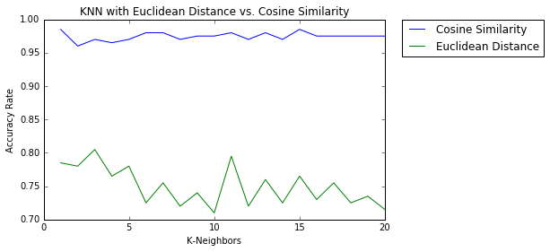

```python
fig = plt.figure(figsize=(15,4))
ax1 = fig.add_subplot(121)
plt.plot(k_range, knn_cosine, label='Cosine Similarity')
plt.plot(k_range, knn_euclidean, label='Euclidean Distance')
ax1.set_title("KNN with Euclidean Distance vs. Cosine Similarity")
ax1.set_xlabel('K-Neighbors')
ax1.set_ylabel('Accuracy Rate')
plt.legend(bbox_to_anchor=(1.05, 1), loc=2, borderaxespad=0.)
```

### Part D

Next I converted the training and test data to arrays to be used to create tf idf dataframes.

```python
train_ar = numpy.array(train)
```

```python
train_ar
```

```
array([[ 2.,  2.,  2., ...,  0.,  0.,  0.],
       [ 0.,  0.,  0., ...,  0.,  0.,  0.],
       [ 0.,  0.,  0., ...,  0.,  0.,  0.],
       ...,
       [ 0.,  0.,  0., ...,  0.,  0.,  0.],
       [ 0.,  0.,  0., ...,  0.,  0.,  0.],
       [ 0.,  0.,  0., ...,  0.,  0.,  0.]])
```

```python
test_ar = numpy.array(test)
```

```python
numTerms = len(train_ar[1])
numTerms
```

```
5500
```

```python
numDocsTrain = len(train_ar)
numDocsTrain
```

```
800
```

```python
numDocsTest = len(test_ar)
numDocsTest
```

```
200
```

```python
termFreqs = train_ar.sum(axis=0)
termFreqs
```

```
array([ 102.,   11.,   22., ...,    2.,    2.,    2.])
```

```python
DocFreq = numpy.array([(train_ar!=0).sum(0)])
DocFreq.shape
```

```
(1, 5500)
```

To get the TF IDF matrices, we first create a matrix the same size as the training and test datasets. Each cell is then populated with 800, which is the document size for the trianing data. At that point, I divide the cells by the termFreqs to get the IDFs. By populaitng the testing with 800 as well, I get uniform IDFs for both testing and training.

In theory, the better option would be to condence the training and test, find the IDFs for each term, redivide the entire dataset and apply the IDFs. For this exercise, I felt it sufficient to gather the IDFs from the training only, as we can assume the test set to be fairly similar to the trianing dataset.

```python
matrix_train = numpy.ones(numpy.shape(train_ar), dtype=float)*numDocsTrain
matrix_test = numpy.ones(numpy.shape(test_ar), dtype=float)*numDocsTrain
numpy.set_printoptions(precision=2,suppress=True,linewidth=120)
```

```python
matrix_train.shape
```

```
(800, 5500)
```

```python
matrix_train
```

```
array([[ 800.,  800.,  800., ...,  800.,  800.,  800.],
       [ 800.,  800.,  800., ...,  800.,  800.,  800.],
       [ 800.,  800.,  800., ...,  800.,  800.,  800.],
       ...,
       [ 800.,  800.,  800., ...,  800.,  800.,  800.],
       [ 800.,  800.,  800., ...,  800.,  800.,  800.],
       [ 800.,  800.,  800., ...,  800.,  800.,  800.]])
```

```python
train_IDF = numpy.log2(numpy.divide(matrix_train,termFreqs))
test_IDF = numpy.log2(numpy.divide(matrix_test,termFreqs))
```

```python
test_IDF
```

```
array([[ 2.97,  6.18,  5.18, ...,  8.64,  8.64,  8.64],
       [ 2.97,  6.18,  5.18, ...,  8.64,  8.64,  8.64],
       [ 2.97,  6.18,  5.18, ...,  8.64,  8.64,  8.64],
       ...,
       [ 2.97,  6.18,  5.18, ...,  8.64,  8.64,  8.64],
       [ 2.97,  6.18,  5.18, ...,  8.64,  8.64,  8.64],
       [ 2.97,  6.18,  5.18, ...,  8.64,  8.64,  8.64]])
```

```python
test_IDF.shape
```

```
(200, 5500)
```

```python
train_IDF
```

```
array([[ 2.97,  6.18,  5.18, ...,  8.64,  8.64,  8.64],
       [ 2.97,  6.18,  5.18, ...,  8.64,  8.64,  8.64],
       [ 2.97,  6.18,  5.18, ...,  8.64,  8.64,  8.64],
       ...,
       [ 2.97,  6.18,  5.18, ...,  8.64,  8.64,  8.64],
       [ 2.97,  6.18,  5.18, ...,  8.64,  8.64,  8.64],
       [ 2.97,  6.18,  5.18, ...,  8.64,  8.64,  8.64]])
```

```python
train_IDF.shape
```

```
(800, 5500)
```

```python
train_TFIDF = train_ar * train_IDF
test_TFIDF = test_ar * test_IDF
```

```python
train_tfidf_pd = pandas.DataFrame(train_TFIDF)
test_tfidf_pd = pandas.DataFrame(test_TFIDF)
```

```python
for k in range(1,21):
    k_nearest_neighbor(train_tfidf_pd, test_tfidf_pd, train_labels, test_labels, 'cosine', k)
    print('\n')
```

```
('K: ', 1)
('Similarity Measure: ', 'cosine')


('Correct: ', 187.0)
('Observations: ', 200.0)
('Accuracy: ', 0.935)


('K: ', 2)
('Similarity Measure: ', 'cosine')


('Correct: ', 190.0)
('Observations: ', 200.0)
('Accuracy: ', 0.95)


('K: ', 3)
('Similarity Measure: ', 'cosine')


('Correct: ', 192.0)
('Observations: ', 200.0)
('Accuracy: ', 0.96)


('K: ', 4)
('Similarity Measure: ', 'cosine')


('Correct: ', 193.0)
('Observations: ', 200.0)
('Accuracy: ', 0.965)


('K: ', 5)
('Similarity Measure: ', 'cosine')


```

[output cut: 123 more lines]

```
('Similarity Measure: ', 'cosine')


('Correct: ', 197.0)
('Observations: ', 200.0)
('Accuracy: ', 0.985)


('K: ', 20)
('Similarity Measure: ', 'cosine')


('Correct: ', 197.0)
('Observations: ', 200.0)
('Accuracy: ', 0.985)
```

```python
for k in range(1,21):
    k_nearest_neighbor(train_tfidf_pd, test_tfidf_pd, train_labels, test_labels, 'euclidean', k)
    print('\n')
```

```
('K: ', 1)
('Similarity Measure: ', 'euclidean')


('Correct: ', 138.0)
('Observations: ', 200.0)
('Accuracy: ', 0.69)


('K: ', 2)
('Similarity Measure: ', 'euclidean')


('Correct: ', 138.0)
('Observations: ', 200.0)
('Accuracy: ', 0.69)


('K: ', 3)
('Similarity Measure: ', 'euclidean')


('Correct: ', 151.0)
('Observations: ', 200.0)
('Accuracy: ', 0.755)


('K: ', 4)
('Similarity Measure: ', 'euclidean')


('Correct: ', 145.0)
('Observations: ', 200.0)
('Accuracy: ', 0.725)


('K: ', 5)
('Similarity Measure: ', 'euclidean')


```

[output cut: 123 more lines]

```
('Similarity Measure: ', 'euclidean')


('Correct: ', 107.0)
('Observations: ', 200.0)
('Accuracy: ', 0.535)


('K: ', 20)
('Similarity Measure: ', 'euclidean')


('Correct: ', 105.0)
('Observations: ', 200.0)
('Accuracy: ', 0.525)
```

```python
knn_euclidean_tfidf = (.69,.69,.755,.725,.755,.665,.675,.615,.615,.585,.61,.57,.58,.55,.55,.55,.55,.535,.535,.525)
```

```python
knn_cosine_tfidf = (.935,.95,.96,.965,.975,.98,.975,.975,.985,.975,.99,.985,.985,.985,.98,.975,.985,.98,.985,.985)
```

Below we see the models run with tf weights vs. tf idf transofmration.

[figure not shown]

```python
fig = plt.figure(figsize=(15,4))
ax1 = fig.add_subplot(121)
plt.plot(k_range, knn_cosine, label='Cosine w/ TF')
plt.plot(k_range, knn_cosine_tfidf, label='Cosine w/ TF IDF')
ax1.set_title("TF vs. TF IDF Using Euclidean")
ax1.set_xlabel('K-Neighbors')
ax1.set_ylabel('Accuracy Rate')
plt.legend(bbox_to_anchor=(1.05, 1), loc=2, borderaxespad=0.)
```

[figure not shown]

```python
fig = plt.figure(figsize=(15,4))
ax1 = fig.add_subplot(121)
plt.plot(k_range, knn_euclidean, label='Euclidean w/ TF')
plt.plot(k_range, knn_euclidean_tfidf, label='Euclidean w/ TF IDF')
ax1.set_title("TF vs. TF IDF Using Cosine Similarity")
ax1.set_xlabel('K-Neighbors')
ax1.set_ylabel('Accuracy Rate')
plt.legend(bbox_to_anchor=(1.05, 1), loc=2, borderaxespad=0.)
```

#### The below function performs Rocchio's Method for classification and takes the following parameters:

```
train: a training term x document matrix in a pandas dataframe
test: a test term x document matrix in a pandas dataframe
train_labels: the labels of the training dataset
test_labels: list of test labels
measure: either 'euclidean' or 'cosine'
```

Similar to the above knn function, this will take a dataframe of test cases, convert them to a numpy array and compare them to the prototype vectors. The prototype vectors are calculated for each class. The function will return the overall accuracy.

```python
test_labels=test_labels.rename(columns = {1:'class'})
```

```python
train_labels=train_labels.rename(columns = {1:'class'})
```

```python
def roc(train, test, train_labels, test_labels, measure):

    #here we create prototype vectors for rocchios method
    tester = pandas.concat([train,train_labels], axis=1)
    prototypes =  pandas.DataFrame(tester.groupby(["class"]).mean())

    #initialize a dataframe to store the similarity measure for each training document
    global final
    ratings = {}
    final = pandas.DataFrame(columns = ('Actual_Class','Predicted_Class'))

    #iterate through the training and test dataframes
    for index_test,row_test in test.iterrows():
        for index_p,row_p in prototypes.iterrows():

            #each loop, we reinitialize the similarity measures
            norm_test = 0
            norm_p = 0
            dot = 0
            euclidean = 0
            cosine = 0

            #convert each row to a numpy array so we can use the linalg and dot functions
            row_test = numpy.array(row_test)
            row_p = numpy.array(row_p)

            #get the euclidean distance
            euclidean = numpy.sqrt(((row_p - row_test)**2).sum(axis=0))
            dist_euclidean = euclidean

            #get the norm for the test and training documents
            norm_test = numpy.linalg.norm(row_test)
            norm_p = numpy.linalg.norm(row_p)

            #get the dot product
            dot = numpy.dot(row_test,row_p)

            #get the cosine similarity
            cosine = dot/(norm_test * norm_p)
            dist_cosine = 1 - cosine

            #if cosine similarity, append to the list
            if measure == 'cosine':
                if index_test not in ratings:
                    ratings[index_test] = []
                    ratings[index_test].append([index_p,dist_cosine])
                else:
                    ratings[index_test].append([index_p,dist_cosine])

            #otherwise use euclidean distance
            else:
                if index_test not in ratings:
                    ratings[index_test] = []
                    ratings[index_test].append([index_p,dist_euclidean])
                else:
                    ratings[index_test].append([index_p,dist_euclidean])

    #begin looping thorugh the ratings dictionary
    for key,value in ratings.items():
        lst = []
        rating = []
        knn = []
        final_ratings = []

        #for each value in the list, we sort based on the similarity measure in decending order
        for item in value:
            lst.append(item)
            lst = sorted(lst,key = lambda tup: tup[1])

        #we chop the top k measuers off
        final_list = lst[:1]

        for item1 in final_list:
            knn.append(item1[0])

        #this gives the final labels
        for item1 in knn:
            final_ratings.append(test_labels.iloc[item1][0])

        #we use the mode to get the predicted class
        predicted = lst[0][0]

        #we append the actual rating and predicted to the final dataframe
        actual_rating = test_labels.iloc[key][0]
        final.loc[key] = (actual_rating, predicted)

        print("Observation: ", key )
        print("Actual Rating: ", actual_rating)
        print("Predicted Rating: ", predicted)
        print("\n")

    final['Predicted_Class'] = final['Actual_Class'] == final['Predicted_Class']
    correct_class = float(final[final.Predicted_Class == True].count()["Predicted_Class"])
    observations = float(len(final.index))
    accuracy = correct_class/observations

    print('\n')
    print("Correct: ",correct_class)
    print("Observations: ", observations)
    print("Accuracy: ", accuracy)
    print('\n')
```

I first run the roc function outputing the predicted and actual class labels.

```python
roc(train, test, train_labels, test_labels, 'euclidean')
```

```
Observation:  0
Actual Rating:  1
Predicted Rating:  1


Observation:  1
Actual Rating:  0
Predicted Rating:  0


Observation:  2
Actual Rating:  0
Predicted Rating:  1


Observation:  3
Actual Rating:  1
Predicted Rating:  1


Observation:  4
Actual Rating:  1
Predicted Rating:  1


Observation:  5
Actual Rating:  0
Predicted Rating:  0


Observation:  6
Actual Rating:  1
Predicted Rating:  1


Observation:  7
Actual Rating:  1
Predicted Rating:  1


```

[output cut: 950 more lines]

```
Observation:  198
Actual Rating:  1
Predicted Rating:  1


Observation:  199
Actual Rating:  1
Predicted Rating:  1




Correct:  188.0
Observations:  200.0
Accuracy:  0.94
```

Below we run the ROC method using euclidean distance. For brevity, I commented out the print and predicted class label printouts.

```python
roc(train, test, train_labels, test_labels, 'euclidean')
```

```
Correct:  188.0
Observations:  200.0
Accuracy:  0.94
```

Below we run the model using the cosine similarity.

```python
roc(train, test, train_labels, test_labels, 'cosine')
```

```
Correct:  195.0
Observations:  200.0
Accuracy:  0.975
```

```python
max_knn_euclidean = max(knn_euclidean)
max_knn_cosine = max(knn_cosine)
max_knn_euclidean_tfidf = max(knn_euclidean_tfidf)
max_knn_cosine_tfidf = max(knn_cosine_tfidf)
roc_euclidean = .94
roc_cosine = .975
```

[figure not shown]

```python
objects = ('K-E', 'K-C', 'K-E-IDF', 'K-C-IDF', 'R-E', 'R-C')
y_pos = numpy.arange(len(objects))
performance = [max_knn_euclidean,max_knn_cosine,max_knn_euclidean_tfidf,max_knn_cosine_tfidf,roc_euclidean,roc_cosine]

plt.bar(y_pos, performance, align='center', alpha=0.5)
plt.xticks(y_pos, objects)
plt.ylabel('Max Accuracy')
plt.title('Classification Paramaters')


plt.show()
```

## Problem 2

### Part A

Next I load the data.

```python
bank = pandas.read_csv('bank_data.csv', sep = ',',index_col = 0, header = 0)
bank.shape
```

```
(600, 11)
```

Next the pep label column is split from the data to act as the target variable. Then I drop this column from the dataset to be used for classification

```python
pep_labels = pandas.DataFrame(bank['pep'])
```

```python
bank = bank.drop('pep', 1)
```

```python
bank.head()
```

| id | age | income | children | gender | region | married | car | savings_acct | current_acct | mortgage |
| --- | --- | --- | --- | --- | --- | --- | --- | --- | --- | --- |
| ID12101 | 48 | 17546.0 | 1 | FEMALE | INNER_CITY | NO | NO | NO | NO | NO |
| ID12102 | 40 | 30085.1 | 3 | MALE | TOWN | YES | YES | NO | YES | YES |
| ID12103 | 51 | 16575.4 | 0 | FEMALE | INNER_CITY | YES | YES | YES | YES | NO |
| ID12104 | 23 | 20375.4 | 3 | FEMALE | TOWN | YES | NO | NO | YES | NO |
| ID12105 | 57 | 50576.3 | 0 | FEMALE | RURAL | YES | NO | YES | NO | NO |

Using pandas, all the categorical variables are convereted to dummies.

```python
bank = pandas.get_dummies(bank)
```

Then the continuous variables age and income are converted to 0-1 scale for normalization purposes.

```python
bank["income"] = (bank["income"] - bank["income"].min()) / (bank["income"].max() - bank["income"].min())
```

```python
bank["age"] = (bank["age"] - bank["age"].min()) / (bank["age"].max() - bank["age"].min())
```

```python
bank["children"] = (bank["children"] - bank["children"].min()) / (bank["children"].max() - bank["children"].min())
```

```python
bank.describe()
```

|  | age | income | children | gender_FEMALE | gender_MALE | region_INNER_CITY | region_RURAL | region_SUBURBAN | region_TOWN | married_NO | married_YES | car_NO | car_YES | savings_acct_NO | savings_acct_YES | current_acct_NO | current_acct_YES | mortgage_NO | mortgage_YES |
| --- | --- | --- | --- | --- | --- | --- | --- | --- | --- | --- | --- | --- | --- | --- | --- | --- | --- | --- | --- |
| count | 600.000000 | 600.000000 | 600.000000 | 600.000000 | 600.000000 | 600.000000 | 600.000000 | 600.000000 | 600.000000 | 600.000000 | 600.000000 | 600.000000 | 600.000000 | 600.000000 | 600.000000 | 600.000000 | 600.000000 | 600.000000 | 600.000000 |
| mean | 0.497857 | 0.387326 | 0.337222 | 0.500000 | 0.500000 | 0.448333 | 0.160000 | 0.103333 | 0.288333 | 0.340000 | 0.660000 | 0.506667 | 0.493333 | 0.310000 | 0.690000 | 0.241667 | 0.758333 | 0.651667 | 0.348333 |
| std | 0.294387 | 0.221961 | 0.352251 | 0.500417 | 0.500417 | 0.497738 | 0.366912 | 0.304648 | 0.453365 | 0.474104 | 0.474104 | 0.500373 | 0.500373 | 0.462879 | 0.462879 | 0.428451 | 0.428451 | 0.476840 | 0.476840 |
| min | 0.000000 | 0.000000 | 0.000000 | 0.000000 | 0.000000 | 0.000000 | 0.000000 | 0.000000 | 0.000000 | 0.000000 | 0.000000 | 0.000000 | 0.000000 | 0.000000 | 0.000000 | 0.000000 | 0.000000 | 0.000000 | 0.000000 |
| 25% | 0.244898 | 0.210791 | 0.000000 | 0.000000 | 0.000000 | 0.000000 | 0.000000 | 0.000000 | 0.000000 | 0.000000 | 0.000000 | 0.000000 | 0.000000 | 0.000000 | 0.000000 | 0.000000 | 1.000000 | 0.000000 | 0.000000 |
| 50% | 0.489796 | 0.342610 | 0.333333 | 0.500000 | 0.500000 | 0.000000 | 0.000000 | 0.000000 | 0.000000 | 0.000000 | 1.000000 | 1.000000 | 0.000000 | 0.000000 | 1.000000 | 0.000000 | 1.000000 | 1.000000 | 0.000000 |
| 75% | 0.760204 | 0.536144 | 0.666667 | 1.000000 | 1.000000 | 1.000000 | 0.000000 | 0.000000 | 1.000000 | 1.000000 | 1.000000 | 1.000000 | 1.000000 | 1.000000 | 1.000000 | 0.000000 | 1.000000 | 1.000000 | 1.000000 |
| max | 1.000000 | 1.000000 | 1.000000 | 1.000000 | 1.000000 | 1.000000 | 1.000000 | 1.000000 | 1.000000 | 1.000000 | 1.000000 | 1.000000 | 1.000000 | 1.000000 | 1.000000 | 1.000000 | 1.000000 | 1.000000 | 1.000000 |

The bank dataframe is then convereted to a numpy array that will be used in the scikit learn modules.

```python
bank = numpy.array(bank)
```

```python
pep_labels = numpy.array(pep_labels)
```

Using skikitlearn, a test and training set is created at 80% training and 20% test.

```python
bank_train, bank_test, bank_target_train, bank_target_test = train_test_split(bank, pep_labels, test_size=0.2, random_state=33)
```

### Part B

First a knn object is created, using k = 5.

```python
n_neighbors = 5
knnclf = neighbors.KNeighborsClassifier(n_neighbors, weights='distance')
knnclf.fit(bank_train, bank_target_train)
```

```
KNeighborsClassifier(algorithm='auto', leaf_size=30, metric='minkowski',
           metric_params=None, n_neighbors=5, p=2, weights='distance')
```

Using the test data, the classes are predicted.

```python
knnpreds_test = knnclf.predict(bank_test)
```

Below we see the confusion matrix and accuracy measures for the knn classifier.

```python
print(classification_report(bank_target_test, knnpreds_test))
```

```
             precision    recall  f1-score   support

         NO       0.68      0.74      0.71        66
        YES       0.65      0.57      0.61        54

avg / total       0.66      0.67      0.66       120
```

```python
knncm = (confusion_matrix(bank_target_test, knnpreds_test))
print(knncm)
```

```
[[49 17]
 [23 31]]
```

We know plot the confusion matrix using pyplot.

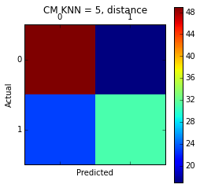

```python
plt.matshow(knncm)
plt.title('CM KNN = 5, distance')
plt.colorbar()
plt.ylabel('Actual')
plt.xlabel('Predicted')
plt.show()
```

Then I use K = 3

```python
n_neighbors = 3
knnclf = neighbors.KNeighborsClassifier(n_neighbors, weights='distance')
knnclf.fit(bank_train, bank_target_train)
```

```
KNeighborsClassifier(algorithm='auto', leaf_size=30, metric='minkowski',
           metric_params=None, n_neighbors=3, p=2, weights='distance')
```

```python
knnpreds_test = knnclf.predict(bank_test)
```

```python
print(classification_report(bank_target_test, knnpreds_test))
```

```
             precision    recall  f1-score   support

         NO       0.68      0.67      0.67        66
        YES       0.60      0.61      0.61        54

avg / total       0.64      0.64      0.64       120
```

```python
knncm = (confusion_matrix(bank_target_test, knnpreds_test))
print(knncm)
```

```
[[44 22]
 [21 33]]
```

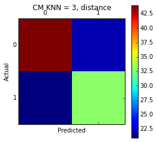

```python
plt.matshow(knncm)
plt.title('CM KNN = 3, distance')
plt.colorbar()
plt.ylabel('Actual')
plt.xlabel('Predicted')
plt.show()
```

Becuase a lower K performed slightly worse, I chose to increase the K to 9.

```python
n_neighbors = 9
knnclf = neighbors.KNeighborsClassifier(n_neighbors, weights='distance')
knnclf.fit(bank_train, bank_target_train)
```

```
KNeighborsClassifier(algorithm='auto', leaf_size=30, metric='minkowski',
           metric_params=None, n_neighbors=9, p=2, weights='distance')
```

```python
knnpreds_test = knnclf.predict(bank_test)
```

```python
print(classification_report(bank_target_test, knnpreds_test))
```

```
             precision    recall  f1-score   support

         NO       0.69      0.71      0.70        66
        YES       0.63      0.61      0.62        54

avg / total       0.67      0.67      0.67       120
```

```python
knncm = (confusion_matrix(bank_target_test, knnpreds_test))
print(knncm)
```

```
[[47 19]
 [21 33]]
```

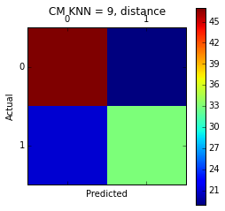

```python
plt.matshow(knncm)
plt.title('CM KNN = 9, distance')
plt.colorbar()
plt.ylabel('Actual')
plt.xlabel('Predicted')
plt.show()
```

In this case, the precision and accuracy seem to be fairly consistent, around .65 for various ks. I will now test adjusting the weight parameter to uniform.

```python
n_neighbors = 5
knnclf = neighbors.KNeighborsClassifier(n_neighbors, weights='uniform')
knnclf.fit(bank_train, bank_target_train)
```

```
KNeighborsClassifier(algorithm='auto', leaf_size=30, metric='minkowski',
           metric_params=None, n_neighbors=5, p=2, weights='uniform')
```

```python
knnpreds_test = knnclf.predict(bank_test)
```

```python
print(classification_report(bank_target_test, knnpreds_test))
```

```
             precision    recall  f1-score   support

         NO       0.69      0.74      0.72        66
        YES       0.65      0.59      0.62        54

avg / total       0.67      0.68      0.67       120
```

```python
knncm = (confusion_matrix(bank_target_test, knnpreds_test))
print(knncm)
```

```
[[49 17]
 [22 32]]
```

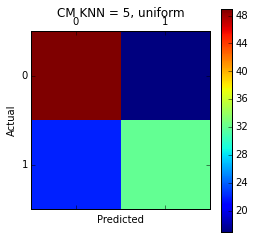

```python
plt.matshow(knncm)
plt.title('CM KNN = 5, uniform')
plt.colorbar()
plt.ylabel('Actual')
plt.xlabel('Predicted')
plt.show()
```

```python
n_neighbors = 3
knnclf = neighbors.KNeighborsClassifier(n_neighbors, weights='uniform')
knnclf.fit(bank_train, bank_target_train)
```

```
KNeighborsClassifier(algorithm='auto', leaf_size=30, metric='minkowski',
           metric_params=None, n_neighbors=3, p=2, weights='uniform')
```

```python
knnpreds_test = knnclf.predict(bank_test)
```

```python
print(classification_report(bank_target_test, knnpreds_test))
```

```
             precision    recall  f1-score   support

         NO       0.69      0.68      0.69        66
        YES       0.62      0.63      0.62        54

avg / total       0.66      0.66      0.66       120
```

```python
knncm = (confusion_matrix(bank_target_test, knnpreds_test))
print(knncm)
```

```
[[45 21]
 [20 34]]
```

[figure not shown]

```python
plt.matshow(knncm)
plt.title('CM KNN = 5, distance')
plt.colorbar()
plt.ylabel('Actual')
plt.xlabel('Predicted')
plt.show()
```

```python
n_neighbors = 9
knnclf = neighbors.KNeighborsClassifier(n_neighbors, weights='uniform')
knnclf.fit(bank_train, bank_target_train)
```

```
KNeighborsClassifier(algorithm='auto', leaf_size=30, metric='minkowski',
           metric_params=None, n_neighbors=9, p=2, weights='uniform')
```

```python
knnpreds_test = knnclf.predict(bank_test)
```

```python
print(classification_report(bank_target_test, knnpreds_test))
```

```
             precision    recall  f1-score   support

         NO       0.68      0.80      0.74        66
        YES       0.69      0.54      0.60        54

avg / total       0.68      0.68      0.68       120
```

```python
knncm = (confusion_matrix(bank_target_test, knnpreds_test))
print(knncm)
```

```
[[53 13]
 [25 29]]
```

[figure not shown]

```python
plt.matshow(knncm)
plt.title('CM KNN = 9, distance')
plt.colorbar()
plt.ylabel('Actual')
plt.xlabel('Predicted')
plt.show()
```

Using uniform returned very similar accuracy measures as using distance calculations. After testing 3 different Ks with different weighting measures, I found the accuracies to be close enough to stop testing. While I found little increased accuracy, I would likely choose 9 as my K with the weighting set to uniform, as this performed slightly better.

### Part C

A decision tree object is created to run a new classification model on the bank data.

```python
treeclf = tree.DecisionTreeClassifier(criterion='entropy', min_samples_split=3)
```

The model is then applied to our test data.

```python
treeclf = treeclf.fit(bank_train, bank_target_train)
```

```python
treepreds_test = treeclf.predict(bank_test)
```

```python
print(treeclf.score(bank_test, bank_target_test))
```

```
0.808333333333
```

```python
print(treeclf.score(bank_train, bank_target_train))
```

```
0.9875
```

In this case, we see a much higher accuracy score for the trianing data, which is 98%. However for the test data the score drops to 80%. This still performs better than the KNN, however the model may be overfitting the training data.

Below we see the confusion matrix and accuracy scores for the confusion matrix.

```python
print(classification_report(bank_target_test, treepreds_test))
```

```
             precision    recall  f1-score   support

         NO       0.81      0.85      0.83        66
        YES       0.80      0.76      0.78        54

avg / total       0.81      0.81      0.81       120
```

Below we see the confusion matrix for the decision tree.

```python
treecm = confusion_matrix(bank_target_test, treepreds_test)
print(treecm)
```

```
[[56 10]
 [13 41]]
```

[figure not shown]

```python
plt.matshow(knncm)
plt.title('CM DT, entropy')
plt.colorbar()
plt.ylabel('Actual')
plt.xlabel('Predicted')
plt.show()
```

Next a Naive Bayes classifier is created.

```python
nbclf = naive_bayes.GaussianNB()
nbclf = nbclf.fit(bank_train, bank_target_train)
nbpreds_test = nbclf.predict(bank_test)
```

```python
print(nbclf.score(bank_train, bank_target_train))
```

```
0.670833333333
```

```python
print(nbclf.score(bank_test, bank_target_test))
```

```
0.591666666667
```

```python
print(classification_report(bank_target_test, nbpreds_test))
```

```
             precision    recall  f1-score   support

         NO       0.62      0.68      0.65        66
        YES       0.55      0.48      0.51        54

avg / total       0.59      0.59      0.59       120
```

```python
treecm = confusion_matrix(bank_target_test, nbpreds_test)
print(treecm)
```

```
[[45 21]
 [28 26]]
```

[figure not shown]

```python
plt.matshow(knncm)
plt.title('CM KNN = 3, distance')
plt.colorbar()
plt.ylabel('Actual')
plt.xlabel('Predicted')
plt.show()
```

### Part D

Based on the above outputs, the best perfroming model was the decision tree classifier with a f score of .81, while the KNN f-score was right around .65. Futhermore, the Naive Bayes classifier performed the worst with the f score of .59. After doing the tests, for this particular dataset, I feel the Decision Tree offered the best approach. To alleivate any concerns about overfitting, it would be beneficial to run cross validation on the model and see if the accuracies are spead widely or fairly consistent. If the overfitting concern remained, I would likely choose the KNN model and continue testing better parameter combinations.

## Problem 3

### Part A

First the data is loaded.

```python
adult = pandas.read_csv('adult-modified.csv', sep = ',', header = 0, na_values=["?"])
```

Next I looked to see if there was any null values. In this case, we see there is as the output is True.

```python
adult.isnull().values.any()
```

```
True
```

```python
adult[adult.workclass.isnull()]
```

|  | age | workclass | education | marital-status | race | sex | hours-per-week | income |
| --- | --- | --- | --- | --- | --- | --- | --- | --- |
| 27 | NaN | NaN | 10 | Married | Asian | Male | 60 | >50K |
| 61 | 32 | NaN | 4 | Married | White | Male | 40 | <=50K |
| 69 | 25 | NaN | 10 | Single | White | Male | 40 | <=50K |
| 77 | 67 | NaN | 6 | Married | White | Male | 2 | <=50K |
| 106 | 17 | NaN | 6 | Single | White | Female | 32 | <=50K |
| 128 | 35 | NaN | 9 | Married | White | Male | 40 | <=50K |
| 149 | 43 | NaN | 10 | Single | White | Female | 40 | <=50K |
| 154 | 52 | NaN | 9 | Single | White | Male | 45 | >50K |
| 160 | 68 | NaN | 2 | Single | White | Female | 20 | <=50K |
| 187 | 53 | NaN | 13 | Single | White | Female | 50 | <=50K |
| 201 | 19 | NaN | 9 | Single | White | Male | 40 | <=50K |
| 221 | 64 | NaN | 2 | Single | White | Male | 40 | <=50K |
| 226 | 60 | NaN | 6 | Single | Amer-Indian | Female | 10 | <=50K |
| 243 | 20 | NaN | 10 | Single | White | Male | 20 | <=50K |
| 266 | 19 | NaN | 10 | Single | White | Male | 24 | <=50K |
| 297 | 39 | NaN | 14 | Married | Asian | Female | 40 | <=50K |
| 312 | 19 | NaN | 10 | Single | Black | Female | 25 | <=50K |
| 326 | 23 | NaN | 11 | Single | Black | Female | 15 | <=50K |
| 346 | 67 | NaN | 7 | Married | White | Male | 8 | <=50K |
| 347 | 30 | NaN | 11 | Single | White | Female | 40 | <=50K |
| 354 | 59 | NaN | 13 | Married | White | Male | 40 | >50K |
| 397 | 20 | NaN | 9 | Single | White | Female | 35 | <=50K |
| 408 | 28 | NaN | 10 | Married | White | Female | 40 | >50K |
| 430 | 80 | NaN | 9 | Married | White | Male | 24 | <=50K |
| 431 | 17 | NaN | 7 | Single | White | Male | 40 | <=50K |
| 449 | 17 | NaN | 7 | Single | White | Female | 5 | <=50K |
| 459 | 32 | NaN | 10 | Married | White | Male | 40 | <=50K |
| 471 | 22 | NaN | 10 | Single | White | Male | 40 | <=50K |
| 484 | 52 | NaN | 8 | Single | Black | Male | 40 | <=50K |
| 486 | 63 | NaN | 2 | Married | White | Male | 35 | <=50K |
| ... | ... | ... | ... | ... | ... | ... | ... | ... |
| 9358 | 18 | NaN | 9 | Single | White | Female | 35 | <=50K |
| 9367 | 17 | NaN | 6 | Single | White | Male | 40 | <=50K |
| 9409 | 22 | NaN | 10 | Single | White | Male | 40 | <=50K |
| 9452 | 19 | NaN | 10 | Single | White | Female | 30 | <=50K |
| 9477 | 19 | NaN | 10 | Single | White | Female | 40 | <=50K |
| 9484 | 48 | NaN | 9 | Married | White | Male | 40 | <=50K |
| 9490 | 18 | NaN | 10 | Single | White | Female | 40 | <=50K |
| 9500 | 27 | NaN | 9 | Married | White | Female | 40 | >50K |
| 9531 | 65 | NaN | 9 | Married | White | Male | 40 | <=50K |
| 9536 | 52 | NaN | 10 | Married | White | Male | 12 | <=50K |
| 9549 | 69 | NaN | 13 | Married | White | Male | 20 | <=50K |
| 9557 | 38 | NaN | 6 | Single | White | Male | 35 | <=50K |
| 9577 | 35 | NaN | 9 | Married | White | Female | 38 | <=50K |
| 9582 | 48 | NaN | 13 | Married | White | Male | 80 | >50K |
| 9616 | 32 | NaN | 9 | Married | White | Male | 40 | <=50K |
| 9626 | 52 | NaN | 15 | Married | Asian | Female | 40 | <=50K |
| 9650 | 69 | NaN | 13 | Married | White | Male | 40 | <=50K |
| 9703 | 55 | NaN | 14 | Married | White | Male | 18 | <=50K |
| 9708 | 19 | NaN | 9 | Single | White | Female | 28 | <=50K |
| 9712 | 30 | NaN | 7 | Single | White | Male | 40 | <=50K |
| 9778 | 67 | NaN | 5 | Married | White | Male | 15 | <=50K |
| 9787 | 49 | NaN | 10 | Single | White | Male | 35 | <=50K |
| 9860 | 20 | NaN | 10 | Single | Asian | Female | 40 | <=50K |
| 9872 | 63 | NaN | 9 | Married | Black | Female | 11 | <=50K |
| 9885 | 68 | NaN | 9 | Married | White | Male | 35 | <=50K |
| 9907 | 68 | NaN | 9 | Married | White | Male | 15 | <=50K |
| 9926 | 73 | NaN | 7 | Married | White | Male | 8 | <=50K |
| 9927 | 18 | NaN | 7 | Single | White | Female | 20 | <=50K |
| 9938 | 36 | NaN | 10 | Single | White | Female | 25 | <=50K |
| 9987 | 67 | NaN | 4 | Married | White | Male | 40 | <=50K |

588 rows × 8 columns

Next, I checked for missing values with respect to the race variable. We see no observations have this as a missing value.

```python
adult[adult.race.isnull()]
```

|  | age | workclass | education | marital-status | race | sex | hours-per-week | income |
| --- | --- | --- | --- | --- | --- | --- | --- | --- |

Then I checked the sex class, and again there was no missing values.

```python
adult[adult.sex.isnull()]
```

|  | age | workclass | education | marital-status | race | sex | hours-per-week | income |
| --- | --- | --- | --- | --- | --- | --- | --- | --- |

Next I checked the income variable. Again, we see no missing values.

```python
adult[adult.income.isnull()]
```

|  | age | workclass | education | marital-status | race | sex | hours-per-week | income |
| --- | --- | --- | --- | --- | --- | --- | --- | --- |

I then drop any row that has a missing value for any of the categorical variables, or more than 1.

```python
adult = adult.dropna(subset=['workclass', 'marital-status', 'race', 'sex', 'income'])
```

After doing so, I checked to see if we still had missing values. Because there was, I applied a function to replace missing continuous variable values with the mean.

```python
adult.isnull().values.any()
```

```
True
```

```python
adult = adult.fillna(adult.mean())
```

When all is said and done, there was 9,412 observations after preprocessing the data accordinly.

```python
adult.isnull().values.any()
```

```
False
```

```python
adult.shape
```

```
(9412, 8)
```

Shown below are the summary statistics for the variables with the cleaned dataset.

```python
adult.describe(include = 'all')
```

|  | age | workclass | education | marital-status | race | sex | hours-per-week | income |
| --- | --- | --- | --- | --- | --- | --- | --- | --- |
| count | 9412.000000 | 9412 | 9412.000000 | 9412 | 9412 | 9412 | 9412.000000 | 9412 |
| unique | NaN | 3 | NaN | 2 | 5 | 2 | NaN | 2 |
| top | NaN | Private | NaN | Married | White | Male | NaN | <=50K |
| freq | NaN | 6947 | NaN | 4737 | 8062 | 6383 | NaN | 7093 |
| mean | 38.364632 | NaN | 10.125266 | NaN | NaN | NaN | 41.080217 | NaN |
| std | 12.962034 | NaN | 2.542118 | NaN | NaN | NaN | 11.884590 | NaN |
| min | 17.000000 | NaN | 1.000000 | NaN | NaN | NaN | 1.000000 | NaN |
| 25% | 28.000000 | NaN | 9.000000 | NaN | NaN | NaN | 40.000000 | NaN |
| 50% | 37.000000 | NaN | 10.000000 | NaN | NaN | NaN | 40.000000 | NaN |
| 75% | 47.000000 | NaN | 13.000000 | NaN | NaN | NaN | 45.000000 | NaN |
| max | 90.000000 | NaN | 16.000000 | NaN | NaN | NaN | 99.000000 | NaN |

Next I created an age distribution histogram with 9 bins.

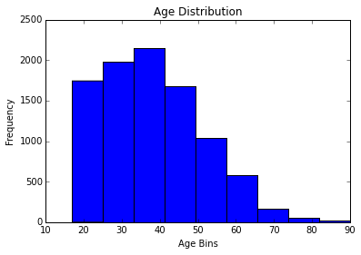

```python
plt.hist(adult["age"], bins = 9)
plt.title("Age Distribution")
plt.xlabel("Age Bins")
plt.ylabel("Frequency")
```

Then I did the same for educational.

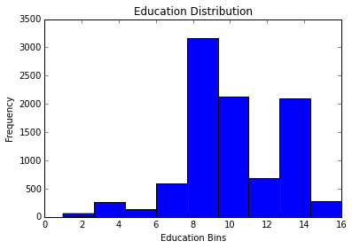

```python
plt.hist(adult["education"], bins = 9)
plt.title("Education Distribution")
plt.xlabel("Education Bins")
plt.ylabel("Frequency")
```

Lastly, this was done for the hours per week variable, which are the 3 continuous variables.

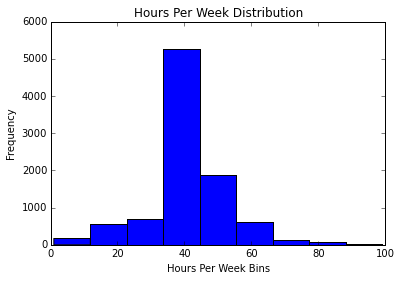

```python
plt.hist(adult["hours-per-week"], bins = 9)
plt.title("Hours Per Week Distribution")
plt.xlabel("Hours Per Week Bins")
plt.ylabel("Frequency")
```

For the categorical variable workclass, I created a bar graphs which are seen below.

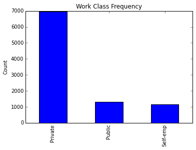

```python
adult["workclass"].value_counts().plot(kind = 'bar', title = "Work Class Frequency")
plt.ylabel('Count')
```

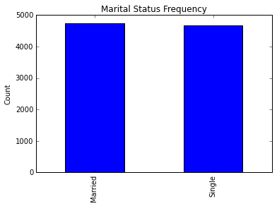

```python
adult["marital-status"].value_counts().plot(kind = 'bar', title = "Marital Status Frequency")
plt.ylabel('Count')
```

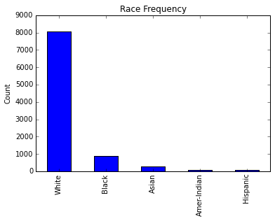

```python
adult["race"].value_counts().plot(kind = 'bar', title = "Race Frequency")
plt.ylabel('Count')
```

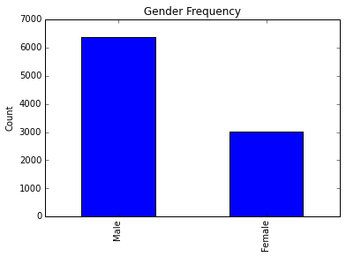

```python
adult["sex"].value_counts().plot(kind = 'bar', title = "Gender Frequency")
plt.ylabel('Count')
```

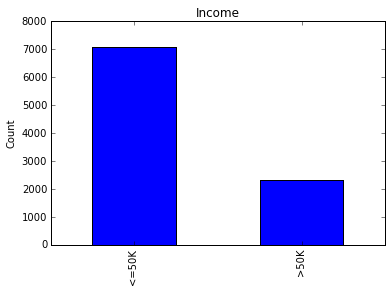

```python
adult["income"].value_counts().plot(kind = 'bar', title = "Income")
plt.ylabel('Count')
```

Cross tabs were created for the combinations of education-race, workclass-income, workclass-race and race-income. As well, the proper visualizations were created for each.

```python
education_race = pandas.crosstab(adult["education"], adult["race"])
education_race
```

| race education | Amer-Indian | Asian | Black | Hispanic | White |
| --- | --- | --- | --- | --- | --- |
| 1 | 0 | 0 | 1 | 0 | 11 |
| 2 | 0 | 1 | 4 | 3 | 38 |
| 3 | 0 | 4 | 5 | 1 | 71 |
| 4 | 5 | 5 | 14 | 6 | 150 |
| 5 | 0 | 3 | 19 | 2 | 118 |
| 6 | 8 | 3 | 30 | 4 | 223 |
| 7 | 4 | 6 | 49 | 4 | 261 |
| 8 | 0 | 2 | 17 | 3 | 78 |
| 9 | 35 | 67 | 350 | 23 | 2590 |
| 10 | 26 | 64 | 206 | 11 | 1818 |
| 11 | 5 | 10 | 33 | 4 | 337 |
| 12 | 4 | 5 | 33 | 3 | 259 |
| 13 | 5 | 75 | 102 | 8 | 1387 |
| 14 | 0 | 27 | 20 | 1 | 467 |
| 15 | 0 | 11 | 5 | 2 | 153 |
| 16 | 0 | 8 | 4 | 0 | 101 |

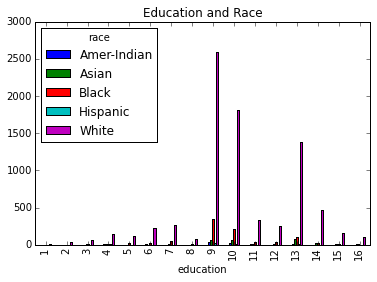

```python
plt.show(education_race.plot(kind = "bar", title = "Education and Race"))
```

```python
work_income = pandas.crosstab(adult["workclass"], adult["income"])
work_income
```

| income workclass | <=50K | >50K |
| --- | --- | --- |
| Private | 5443 | 1504 |
| Public | 925 | 392 |
| Self-emp | 725 | 423 |

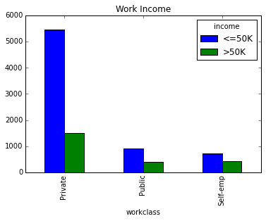

```python
plt.show(work_income.plot(kind = "bar", title = "Work Income"))
```

```python
work_race = pandas.crosstab(adult["workclass"], adult["race"])
work_race
```

| race workclass | Amer-Indian | Asian | Black | Hispanic | White |
| --- | --- | --- | --- | --- | --- |
| Private | 65 | 204 | 664 | 64 | 5950 |
| Public | 20 | 48 | 192 | 5 | 1052 |
| Self-emp | 7 | 39 | 36 | 6 | 1060 |

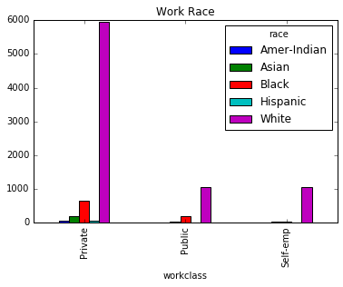

```python
plt.show(work_race.plot(kind = "bar", title = "Work Race"))
```

```python
race_income = pandas.crosstab(adult["race"], adult["income"])
race_income
```

| income race | <=50K | >50K |
| --- | --- | --- |
| Amer-Indian | 83 | 9 |
| Asian | 224 | 67 |
| Black | 773 | 119 |
| Hispanic | 69 | 6 |
| White | 5944 | 2118 |

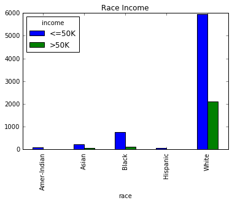

```python
plt.show(race_income.plot(kind = "bar", title = "Race Income"))
```

```python
race_income_df = pandas.DataFrame(race_income)
```

```python
race_income_df.head()
```

| income race | <=50K | >50K |
| --- | --- | --- |
| Amer-Indian | 83 | 9 |
| Asian | 224 | 67 |
| Black | 773 | 119 |
| Hispanic | 69 | 6 |
| White | 5944 | 2118 |

To create a cross tabular showing the percentage of race in low income race-income I created a dataframe. I then added a total_race column and then a column that divided low income raw numbers with the total. For visual purporses, I used a simple bar plot.

```python
race_income_df['total_race'] = race_income_df['<=50K'] + race_income_df['>50K']
race_income_df['percent_low_income'] = race_income_df['<=50K'] / race_income_df['total_race']
```

```python
race_income_df.head()
```

| income race | <=50K | >50K | total_race | percent_low_income |
| --- | --- | --- | --- | --- |
| Amer-Indian | 83 | 9 | 92 | 0.902174 |
| Asian | 224 | 67 | 291 | 0.769759 |
| Black | 773 | 119 | 892 | 0.866592 |
| Hispanic | 69 | 6 | 75 | 0.920000 |
| White | 5944 | 2118 | 8062 | 0.737286 |

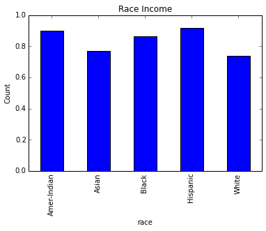

```python
race_income["percent_low_income"].plot(kind = 'bar', title = "Race Income")
plt.ylabel('Count')
```

To compare the summary statistics for each income class, I created a dataframe for each class and performed the describe function

```python
less_50 = adult.income=='<=50K'
less_50_df = adult[less_50]
```

```python
great_50 = adult.income=='>50K'
great_50_df = adult[great_50]
```

```python
less_50_df.describe()
```

|  | age | education | hours-per-week |
| --- | --- | --- | --- |
| count | 7093.000000 | 7093.000000 | 7093.000000 |
| mean | 36.642971 | 9.646976 | 39.567038 |
| std | 13.339926 | 2.397358 | 11.868506 |
| min | 17.000000 | 1.000000 | 1.000000 |
| 25% | 26.000000 | 9.000000 | 38.000000 |
| 50% | 35.000000 | 9.000000 | 40.000000 |
| 75% | 45.000000 | 10.000000 | 40.000000 |
| max | 90.000000 | 16.000000 | 99.000000 |

```python
great_50_df.describe()
```

|  | age | education | hours-per-week |
| --- | --- | --- | --- |
| count | 2319.000000 | 2319.000000 | 2319.000000 |
| mean | 43.630585 | 11.588185 | 45.708495 |
| std | 10.043148 | 2.410764 | 10.678794 |
| min | 19.000000 | 2.000000 | 1.000000 |
| 25% | 36.000000 | 9.000000 | 40.000000 |
| 50% | 43.000000 | 12.000000 | 40.000000 |
| 75% | 50.000000 | 13.000000 | 50.000000 |
| max | 90.000000 | 16.000000 | 99.000000 |

We. see that there is almost 3 times as many low income observations as high income observations. To no surprise, low income observations worked less hours per week, 39 vs 46, than high income observations. As well, higher income observations have roughly 2 additional years of education. Lastly, high income observations are roughly 7 years older. This indicates high income observations are later in life, which offers more experience, more time for education and likely a better income.

### Part B

```python
target = adult['income']
```

Using pandas, the necessary dummy variables were created and the continuous variables age, hours per week and education were rescaled to 0-1.

```python
dummies = pandas.get_dummies(adult)
```

```python
dummies["age"] = (dummies["age"] - dummies["age"].min()) / (dummies["age"].max() - dummies["age"].min())
```

```python
dummies["education"] = (dummies["education"] - dummies["education"].min()) / (dummies["education"].max() - dummies["education"].min())
```

```python
dummies["hours-per-week"] = (dummies["hours-per-week"] - dummies["hours-per-week"].min()) / (dummies["hours-per-week"].max() - dummies["hours-per-week"].min())
```

The 2 income dummy variables were dropped since they won't be used for training the model.

```python
dummies = dummies.drop('income_<=50K', 1)
```

```python
dummies = dummies.drop('income_>50K', 1)
```

For the below machine learning algorithms, I utilized cross validation, 10 fold, which negated the need for a training and test set. Therefore, this step is skipped. Instead, I just feed in all the data and the labels and run the K folds.

```python
nbclf = naive_bayes.GaussianNB()
nbclf = nbclf.fit(dummies, target)
```

```python
cv_scores = cross_validation.cross_val_score(nbclf, dummies, target, cv=10)
print("Overall Accuracy: %0.2f (+/- %0.2f)" % (cv_scores.mean(), cv_scores.std() * 2))
```

```
Overall Accuracy: 0.72 (+/- 0.02)
```

```python
treeclf = tree.DecisionTreeClassifier(criterion='entropy', min_samples_split=3)
treeclf = treeclf.fit(dummies, target)
```

```python
cv_scores = cross_validation.cross_val_score(treeclf, dummies, target, cv=10)
print("Overall Accuracy: %0.2f (+/- %0.2f)" % (cv_scores.mean(), cv_scores.std() * 2))
```

```
Overall Accuracy: 0.77 (+/- 0.03)
```

```python
ldclf = LDA()
ldclf = ldclf.fit(dummies, target)
```

```python
cv_scores = cross_validation.cross_val_score(ldclf, dummies, target, cv=10)
print("Overall Accuracy: %0.2f (+/- %0.2f)" % (cv_scores.mean(), cv_scores.std() * 2))
```

```
Overall Accuracy: 0.81 (+/- 0.02)
```

Based on the above, I would utilize the LDA approach for this dataset, as the classification was the best of the 3 models. The second best was the decision tree with the Naive performing the worst.

One such option would be running the K Nearest Neighbor alogirthm or the Rocchio's Method and comparing those models as well.

```python
tree.export_graphviz(treeclf,out_file='tree.dot', feature_names=
['Age',
 'Education',
 'Hours_Per_Week',
 'Workclass_Private',
 'Workclass_Public',
 'Workclass_Self-Employed',
 'Married',
 'Single',
 'Amer-Indian',
 'Asian', 'Black',
 'Hispanic',
 'White',
 'Female',
 'Male'
 ])
```

The file for the tree graph is included in the zip. Visualizing it within the notebook offered very little.